# SDSU AI Club Python Tutorial

Welcome to the SDSU AI club's Pyhton tutorial! This will be a tutorial that focuses on both python fundamentals as well as the usage of libraires.

# I've got the world on a string: Python and strings

Here are some pointers about strings and python.

Although it may seem very rudimentary, here are some methods of printing strings:

```python
sc='30'
chef='Stephen Curry wears the number ' + str(sc)
print(chef)
print("This python tutorial is the best isn't it?")
```

```
Stephen Curry wears the number 30
This python tutorial is the best isn't it?
```

If statements differ in python from other languages, as they don't need to be placed with {} and instead they use the :. In addition, this means that the else, if, and eslif statements don't need to be placed within the {}and now just after the : clause. We will show you how to complete a few if, else and elif statements in the following statements.

```python
exercise_level=5
mood="Pumped"
if exercise_level >= 4:
    print 'Feeling good bro!'
if mood== 'Sick' or exercise_level >= 7:
    print 'Feeling ripped bro!'
elif mood == 'Pain' or exercise_level >=5:
    print 'No pain, no gain bro!'
else:
    print 'You are an alphalete'
```

```
Feeling good bro!
No pain, no gain bro!
```

Now try the strings1.py exercise in the google folder

# I've got something to check off my lists: Python and lists

Python's for loops look similar to the for loops that many of us have seen in other languages. However, Python also uses the in construct which helps us look into the lists that we desire. For example, in the for loop below, we use the in to set the for loop in motion using the numbers that we have selected.

```python
add= [1,10,25,30,100,250]
for i in add:
    print(i+i)
```

```
2
20
50
60
200
500
```

Again, we can use the in construct in an if statement to determine wether there is a desired value or number in the list that we are examining. This again helps demonstrate the importance of the in construct as it can easily be used for other loops and statemnts.

```python
nba = ['Curry', 'Lebron', 'Durant', 'Harden', 'Giannis']
if 'Curry' in nba:
    print 'Greatest of all time'
```

```
Greatest of all time
```

Now that we have discussed the power of the in construct in lists, we can now look at list methods that we can use when manipulating lists.

```python
list = ['Curry', 'Lebron', 'Durant','Harden','Giannis']
list.append('Embiid')         ## adds Embiid at the end of the list
list.insert(1, 'Klay')        ## inserts Klay at index of 1
list.extend(['Kawhi', 'Gobert'])  ## Extends the list by adding Kawhi and Gobert to the end
print list
print list.index('Durant')
list.remove('Lebron')         ## search and remove that element
print list  ## Prints the final list after
```

```
['Curry', 'Klay', 'Lebron', 'Durant', 'Harden', 'Giannis', 'Embiid', 'Kawhi', 'Gobert']
3
['Curry', 'Klay', 'Durant', 'Harden', 'Giannis', 'Embiid', 'Kawhi', 'Gobert']
```

Sorting is similar to other languages, but there are some cool things that we can do with custom sorting. We can custom sort lists with our own criteria. In the example below, we can sort the list according to length.

```python
examp= ['biggie', 'Pac', 'OutKast', 'NWA','Wu Tang', 'Yezzus', 'Blueface']
print sorted(examp, key=len)
```

```
['Pac', 'NWA', 'biggie', 'Yezzus', 'OutKast', 'Wu Tang', 'Blueface']
```

Tuples are another way of sorting lists but they are immutable and can not change size. Tuples are like structs are a way to pass around a small, logical and fixed size set of values.

```python
 tuple = ('A', 'tribe', 'called')
print len(tuple)
print tuple[2]
##tuple[2] = 'OutKast'  ## This does not work because tuples can not be changed
tuple = ('A', 'tribe', 'called','Quest')
print tuple
```

```
3
called
('A', 'tribe', 'called', 'Quest')
```

# Let's look it up in the Dictionary: Python and dictionaries

Dictionaries in python are very similar to lists, as they are both mutable and dynamic. Unlike lists, dictionaries index elements by keys which can in turn be strings.

```python
dict = {}
dict['w'] = 'warriors'
dict['j'] = 'jazz'
dict['s'] = 'spurs'

print dict

print dict['j']
dict['j'] = 6
## Throws KeyError
if 'z' in dict: print dict['z']     ## Avoid KeyError
print dict.get('z')  ## None (instead of KeyError)
```

```
{'s': 'spurs', 'j': 'jazz', 'w': 'warriors'}
jazz
None
```

# Express yourself: Python and regular expressions

Regular expressions are a powerful language that help us match text patterns. When we use regular expressions, we make sure to add the 're' module. Again, here are three different examples

```python
import re
re.compile('<title>(.*)</title>')
```

```
re.compile(r'<title>(.*)</title>')
```

```python
str = 'an example word:OutKast!!'
match = re.search(r'word:\w\w\w\w\w\w\w', str) #search for word of that length
if match:
    print 'found', match.group() ## 'found word:OutKast'
else:
    print 'did not find'
```

```
found word:OutKast
```

```python
str = 'warriors_fan-sc@aol.com'
match = re.search(r'\w+@\w+', str)
if match:
    print match.group()
```

```
sc@aol
```

```python
  str = 'warriors_fan-sc@bing.com '
  match = re.search(r'([\w.-]+)@([\w.-]+)', str)
  if match:
    print match.group()
    print match.group(1) #break up the string into two parts divided by the @
    print match.group(2)
```

```
warriors_fan-sc@bing.com
warriors_fan-sc
bing.com
```

# Donde esta la biblioteca: Python and its libraries

```python
import pandas as pd
from matplotlib import pyplot as plt
import seaborn as sb
import numpy as np
```

These are just a few of the libraries that we will demonstrate today.

Pandas is the most powerful tool for those of us using python and have an interest in machine learning and artificial intellligence. So what makes pandas so great, well here are some reasons: it can do calculations for us, clean data up by removing missing data, visulaize the data using matplotlib, and filter rows and columns by criteria.

```python
#from here we will begin to use pandas
nba_df=pd.read_csv("/Users/Antoine/Documents/nba.csv")
nba_df.head()
```

|  | Rk | Team | G | MP | FG | FGA | FG% | 3P | 3PA | 3P% | ... | FT% | ORB | DRB | TRB | AST | STL | BLK | TOV | PF | PTS |
| --- | --- | --- | --- | --- | --- | --- | --- | --- | --- | --- | --- | --- | --- | --- | --- | --- | --- | --- | --- | --- | --- |
| 0 | 1.0 | Milwaukee Bucks* | 82 | 241.2 | 43.4 | 91.1 | 0.476 | 13.5 | 38.2 | 0.353 | ... | 0.773 | 9.3 | 40.4 | 49.7 | 26.0 | 7.5 | 5.9 | 13.9 | 19.6 | 118.1 |
| 1 | 2.0 | Golden State Warriors* | 82 | 241.5 | 44.0 | 89.8 | 0.491 | 13.3 | 34.4 | 0.385 | ... | 0.801 | 9.7 | 36.5 | 46.2 | 29.4 | 7.6 | 6.4 | 14.3 | 21.4 | 117.7 |
| 2 | 3.0 | New Orleans Pelicans | 82 | 240.9 | 43.7 | 92.2 | 0.473 | 10.3 | 29.9 | 0.344 | ... | 0.761 | 11.1 | 36.2 | 47.3 | 27.0 | 7.4 | 5.4 | 14.8 | 21.1 | 115.4 |
| 3 | 4.0 | Philadelphia 76ers* | 82 | 241.5 | 41.5 | 88.2 | 0.471 | 10.8 | 30.2 | 0.359 | ... | 0.771 | 10.9 | 36.9 | 47.8 | 26.9 | 7.4 | 5.3 | 14.9 | 21.3 | 115.2 |
| 4 | 5.0 | Los Angeles Clippers* | 82 | 241.8 | 41.3 | 87.5 | 0.471 | 10.0 | 25.8 | 0.388 | ... | 0.792 | 9.7 | 35.8 | 45.5 | 24.0 | 6.8 | 4.7 | 14.5 | 23.3 | 115.1 |

5 rows × 25 columns

```python
nba_df.tail(5)
#This will show us the last 5 rows
#Now we can see the stats for the bottom 4 teams as well as the league average
```

|  | Rk | Team | G | MP | FG | FGA | FG% | 3P | 3PA | 3P% | ... | FT% | ORB | DRB | TRB | AST | STL | BLK | TOV | PF | PTS |
| --- | --- | --- | --- | --- | --- | --- | --- | --- | --- | --- | --- | --- | --- | --- | --- | --- | --- | --- | --- | --- | --- |
| 26 | 27.0 | Chicago Bulls | 82 | 242.7 | 39.8 | 87.9 | 0.453 | 9.1 | 25.9 | 0.351 | ... | 0.783 | 8.8 | 34.1 | 42.9 | 21.9 | 7.4 | 4.3 | 14.1 | 20.3 | 104.9 |
| 27 | 28.0 | New York Knicks | 82 | 241.2 | 38.2 | 88.3 | 0.433 | 10.0 | 29.5 | 0.340 | ... | 0.759 | 10.5 | 34.3 | 44.7 | 20.1 | 6.8 | 5.1 | 14.0 | 20.9 | 104.6 |
| 28 | 29.0 | Cleveland Cavaliers | 82 | 240.9 | 38.9 | 87.6 | 0.444 | 10.3 | 29.1 | 0.355 | ... | 0.792 | 10.7 | 31.9 | 42.7 | 20.7 | 6.5 | 2.4 | 13.5 | 20.0 | 104.5 |
| 29 | 30.0 | Memphis Grizzlies | 82 | 242.4 | 38.0 | 84.4 | 0.450 | 9.9 | 28.9 | 0.342 | ... | 0.772 | 8.8 | 33.0 | 41.8 | 23.9 | 8.3 | 5.5 | 14.0 | 22.0 | 103.5 |
| 30 | NaN | League Average | 82 | 241.6 | 41.1 | 89.2 | 0.461 | 11.4 | 32.0 | 0.355 | ... | 0.766 | 10.3 | 34.8 | 45.2 | 24.6 | 7.6 | 5.0 | 14.1 | 20.9 | 111.2 |

5 rows × 25 columns

```python
nba_df.info()
```

```
<class 'pandas.core.frame.DataFrame'>
RangeIndex: 31 entries, 0 to 30
Data columns (total 25 columns):
Rk      30 non-null float64
Team    31 non-null object
G       31 non-null int64
MP      31 non-null float64
FG      31 non-null float64
FGA     31 non-null float64
FG%     31 non-null float64
3P      31 non-null float64
3PA     31 non-null float64
3P%     31 non-null float64
2P      31 non-null float64
2PA     31 non-null float64
2P%     31 non-null float64
FT      31 non-null float64
FTA     31 non-null float64
FT%     31 non-null float64
ORB     31 non-null float64
DRB     31 non-null float64
TRB     31 non-null float64
AST     31 non-null float64
STL     31 non-null float64
BLK     31 non-null float64
TOV     31 non-null float64
PF      31 non-null float64
PTS     31 non-null float64
dtypes: float64(23), int64(1), object(1)
memory usage: 6.1+ KB
```

Now we will apply some matplotlib plots to better visualize our data using plots. In addition, we can use seaborn to better visualize

```python
categories = np.unique(nba_df['Team'])
colors = [plt.cm.tab10(i/float(len(categories)-1)) for i in range(len(categories))]

# Draw Plot for Each Category
plt.figure(figsize=(16, 10), dpi= 80, facecolor='w', edgecolor='k')

for i, category in enumerate(categories):
    plt.scatter('PTS', 'Team',
                data=nba_df.loc[nba_df.Team==Team, :],
                s=20, c=colors[i], label=str(Team))

# Decorations
plt.gca().set(xlim=(0.0, 0.1), ylim=(0, 90000),
              xlabel='Teams', ylabel='PTS')

plt.xticks(fontsize=12); plt.yticks(fontsize=12)
plt.title("Scatterplot of NBA Teams vs PPG", fontsize=22)
plt.legend(fontsize=12)
plt.show()
```

[output not shown]

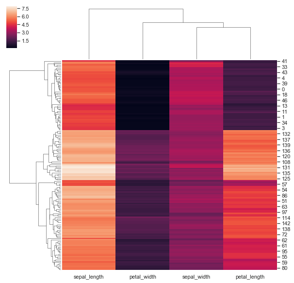

```python
import seaborn as sns; sns.set(color_codes=True)
iris = sns.load_dataset("iris")
species = iris.pop("species")
g = sns.clustermap(iris)
```

```python
url = 'https://raw.githubusercontent.com/BigDataGal/Python-for-Data-Science/master/titanic-train.csv'
titanic = pd.read_csv(url)
titanic.columns = ['PassengerId','Survived','Pclass','Name','Sex','Age','SibSp','Parch','Ticket','Fare','Cabin','Embarked']
titanic.head()
```

|  | PassengerId | Survived | Pclass | Name | Sex | Age | SibSp | Parch | Ticket | Fare | Cabin | Embarked |
| --- | --- | --- | --- | --- | --- | --- | --- | --- | --- | --- | --- | --- |
| 0 | 1 | 0 | 3 | Braund, Mr. Owen Harris | male | 22.0 | 1 | 0 | A/5 21171 | 7.2500 | NaN | S |
| 1 | 2 | 1 | 1 | Cumings, Mrs. John Bradley (Florence Briggs Th... | female | 38.0 | 1 | 0 | PC 17599 | 71.2833 | C85 | C |
| 2 | 3 | 1 | 3 | Heikkinen, Miss. Laina | female | 26.0 | 0 | 0 | STON/O2. 3101282 | 7.9250 | NaN | S |
| 3 | 4 | 1 | 1 | Futrelle, Mrs. Jacques Heath (Lily May Peel) | female | 35.0 | 1 | 0 | 113803 | 53.1000 | C123 | S |
| 4 | 5 | 0 | 3 | Allen, Mr. William Henry | male | 35.0 | 0 | 0 | 373450 | 8.0500 | NaN | S |

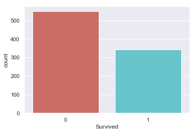

```python
sb.countplot(x='Survived', data=titanic, palette='hls')
```

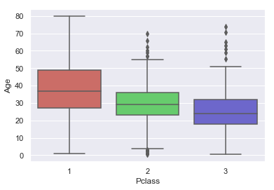

```python
sb.boxplot(x='Pclass', y='Age', data=titanic, palette='hls')
```

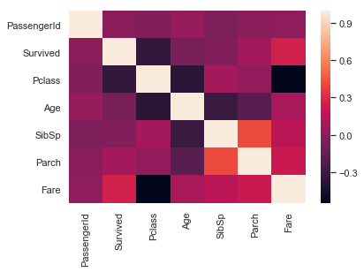

```python
sb.heatmap(titanic.corr())
```

This is a demonstration of numpy and its ability to deal with arrays. We will first be showing you some of the neat features when it comes to creating an array with numpy and then we will be showing you some of the array arithmetic that we can do with numpy.

```python
a = np.array([1, 2, 3,6,7,9,10])   # Create a rank 1 array
print(a.shape)
a[0] = 5                  # Change an element of the array
print(a)
b = np.array([[1,2,3],[4,5,6]])
print(b.shape)
print(b[0, 0], b[0, 1], b[1, 0])
```

```
(7,)
[ 5  2  3  6  7  9 10]
(2, 3)
(1, 2, 4)
```

```python
a = np.zeros((4,4))   # Create an array of all zeros
print(a)

b = np.ones((1,4))    # Create an array of all ones
print(b)

c = np.full((2,2), 42)  # Create a constant array
print(c)

d = np.eye(2)         # Create a 2x2 identity matrix
print(d)

e = np.random.random((4,4))  # Create an array filled with random values
print(e)
```

```
[[0. 0. 0. 0.]
 [0. 0. 0. 0.]
 [0. 0. 0. 0.]
 [0. 0. 0. 0.]]
[[1. 1. 1. 1.]]
[[42 42]
 [42 42]]
[[1. 0.]
 [0. 1.]]
[[0.52055896 0.35982518 0.34580113 0.13836182]
 [0.3824969  0.8951932  0.71111179 0.59833005]
 [0.25423133 0.20713535 0.51561979 0.01864138]
 [0.99357889 0.20936932 0.89639725 0.12495692]]
```

```python
x = np.array([[1,2],[3,4]], dtype=np.float64)
y = np.array([[5,6],[7,8]], dtype=np.float64)


print(x + y)
print(np.add(x, y))
```

```
[[ 6.  8.]
 [10. 12.]]
[[ 6.  8.]
 [10. 12.]]
```

```python
print(x - y)
print(np.subtract(x, y))
```

```
[[-4. -4.]
 [-4. -4.]]
[[-4. -4.]
 [-4. -4.]]
```

```python
print(x * y)
print(np.multiply(x, y))
```

```
[[ 5. 12.]
 [21. 32.]]
[[ 5. 12.]
 [21. 32.]]
```

```python
print(x / y)
print(np.divide(x, y))
```

```
[[0.2        0.33333333]
 [0.42857143 0.5       ]]
[[0.2        0.33333333]
 [0.42857143 0.5       ]]
```

```python
print(np.sqrt(x))
```

```
[[1.         1.41421356]
 [1.73205081 2.        ]]
```